# MovieLens Recommendation System - Code

Uday Adusumilli

16 Dec, 2021

```r
# Install all needed libraries if it is not present

if(!require(tidyverse)) install.packages("tidyverse")
if(!require(kableExtra)) install.packages("kableExtra")
```

```r
if(!require(tidyr)) install.packages("tidyr")
if(!require(tidyverse)) install.packages("tidyverse")
if(!require(stringr)) install.packages("stringr")
if(!require(forcats)) install.packages("forcats")
if(!require(ggplot2)) install.packages("ggplot2")

if(!require(readr)) install.packages("readr")
if(!require(dplyr)) install.packages("dplyr")
if(!require(gridExtra)) install.packages("gridExtra")
if(!require(dslabs)) install.packages("dslabs")
if(!require(data.table)) install.packages("data.table")
if(!require(ggrepel)) install.packages("ggrepel")
if(!require(ggthemes)) install.packages("ggthemes")
# Loading all needed libraries

library(dplyr)
library(tidyverse)
library(kableExtra)
library(tidyr)
library(stringr)
library(forcats)
library(ggplot2)

library(readr)
library(gridExtra)
library(dslabs)
library(data.table)
library(ggrepel)
library(ggthemes)

#############################################################
# Create edx set, validation set, and submission file
#############################################################

# Note: this process could take a couple of minutes

if(!require(tidyverse)) install.packages("tidyverse", repos = "http://cran.us.r-project.org")
if(!require(caret)) install.packages("caret", repos = "http://cran.us.r-project.org")
# MovieLens 10M dataset:
# https://grouplens.org/datasets/movielens/10m/
# http://files.grouplens.org/datasets/movielens/ml-10m.zip
```

The following block needs to be executed if the data isn’t available locally. Execution of the following block requires an active internet connection.

```r
dl <- tempfile()
download.file("http://files.grouplens.org/datasets/movielens/ml-10m.zip", dl)

ratings <- read.table(text = gsub("::", "\t", readLines(unzip(dl, "ml-10M100K/ratings.dat"))),
                      col.names = c("userId", "movieId", "rating", "timestamp"))


movies <- str_split_fixed(readLines(unzip(dl, "ml-10M100K/movies.dat")), "\\::", 3)
```

Execution of the following block requires the data files to be preset in the ml-10M100K folder. The following block is an alternative to the above block.

```r
# ratings <- read.table(text = gsub("::", "\t", readLines("ml-10M100K/ratings.dat")),
#                       col.names = c("userId", "movieId", "rating", "timestamp"))
#
# movies <- str_split_fixed(readLines("ml-10M100K/movies.dat"), "\\::", 3)
```

With the execution of the above block, data loading is complete.

```r
colnames(movies) <- c("movieId", "title", "genres")

movies_old <- as.data.frame(movies) %>% mutate(
                                           movieId = as.numeric(movieId),
                                           title = as.character(title),
                                           genres = as.character(genres))# modified

movies = subset(movies_old, select = c(movieId,title,genres))

movielens <- left_join(ratings, movies, by = "movieId")

# Validation set will be 10% of MovieLens data

set.seed(1, sample.kind = "Rounding") # if using R 3.5 or earlier, use `set.seed(1)` instead
test_index <- createDataPartition(y = movielens$rating, times = 1, p = 0.1, list = FALSE)
edx <- movielens[-test_index,]
temp <- movielens[test_index,]

# Make sure userId and movieId in validation set are also in edx set

validation <- temp %>%
  semi_join(edx, by = "movieId") %>%
  semi_join(edx, by = "userId")

# Add rows removed from validation set back into edx set

removed <- anti_join(temp, validation)
edx <- rbind(edx, removed)

rm(dl, ratings, movies, test_index, temp, movielens, removed)

library(kableExtra)
```

```r
# head(edx)
```

# Executive Summary

The purpose for this project is creating a recommender system using MovieLens dataset.

The version of movielens dataset used for this final assignment contains approximately 10 Milions of movies ratings, divided in 9 Milions for training and one Milion for validation. It is a small subset of a much larger (and famous) dataset with several millions of ratings. Into the training dataset there are approximately **70.000 users** and **11.000 different movies** divided in 20 genres such as Action, Adventure, Horror, Drama, Thriller and more.

After a initial data exploration, the recommender systems builted on this dataset are evaluated and choosen based on the RMSE - Root Mean Squared Error that should be at least lower than **0.87750**.

$$\mbox{RMSE} = \sqrt{\frac{1}{n}\sum_{t=1}^{n}e_t^2}$$

```r
# The RMSE function that will be used in this project is:
RMSE <- function(true_ratings = NULL, predicted_ratings = NULL) {
    sqrt(mean((true_ratings - predicted_ratings)^2))
}
```

# Exploratory Data Analysis

## Inital data Exploration

The 10 Millions dataset is divided into two dataset: `edx` for training purpose and `validation` for the validation phase.

The `edx` dataset contains approximately 9 Millions of rows with 70.000 different users and 11.000 movies with rating score between 0.5 and 5. There is no missing values (0 or NA).

**edx dataset**

```r
edx %>% summarize(Users = n_distinct(userId),
              Movies = n_distinct(movieId)) %>%
kable() %>%
   kable_styling(bootstrap_options = c("striped", "hover", "condensed", "responsive"),
                 position = "center",
                 font_size = 10,
                 full_width = FALSE)
```

| Users | Movies |
| --- | --- |
| 69878 | 10677 |

**Missing Values per Column**

```r
# edx <- edx %>% select(-X)
# validation <- validation %>% select(-X)
```

```r
sapply(edx, function(x) sum(is.na(x))) %>%
kable() %>%
   kable_styling(bootstrap_options = c("striped", "hover", "condensed", "responsive"),
                 position = "center",
                 font_size = 10,
                 full_width = FALSE)
```

|  | x |
| --- | --- |
| userId | 0 |
| movieId | 0 |
| rating | 0 |
| timestamp | 0 |
| title | 0 |
| genres | 0 |

The features/variables/columns in both datasets are six:

- **userId** `<integer>` that contains the unique identification number for each user.
- **movieId** `<numeric>` that contains the unique identification number for each movie.
- **rating** `<numeric>` that contains the rating of one movie by one user. Ratings are made on a 5-Star scale with half-star increments.
- **timestamp** `<integer>` that contains the timestamp for one specific rating provided by one user.
- **title** `<character>` that contains the title of each movie including the year of the release.
- **genres** `<character>` that contains a list of pipe-separated of genre of each movie.

**First 6 Rows of edx dataset**

```r
head(edx) %>%
   kable() %>%
   kable_styling(bootstrap_options = c("striped", "hover", "condensed", "responsive"),
                 position = "center",
                 font_size = 10,
                 full_width = FALSE)
```

|  | userId | movieId | rating | timestamp | title | genres |
| --- | --- | --- | --- | --- | --- | --- |
| 1 | 1 | 122 | 5 | 838985046 | Boomerang (1992) | Comedy\|Romance |
| 2 | 1 | 185 | 5 | 838983525 | Net, The (1995) | Action\|Crime\|Thriller |
| 4 | 1 | 292 | 5 | 838983421 | Outbreak (1995) | Action\|Drama\|Sci-Fi\|Thriller |
| 5 | 1 | 316 | 5 | 838983392 | Stargate (1994) | Action\|Adventure\|Sci-Fi |
| 6 | 1 | 329 | 5 | 838983392 | Star Trek: Generations (1994) | Action\|Adventure\|Drama\|Sci-Fi |
| 7 | 1 | 355 | 5 | 838984474 | Flintstones, The (1994) | Children\|Comedy\|Fantasy |

## Dataset Pre-Processing and Feature Engineering

After a initial data exploration, we notice that the `genres` are pipe-separated values. It’s necessary to extract them for more consisten, robust and precise estimate. We also observe that the `title` contains the year where the movie war released and this it could be necessary to predic the movie rating. Finally, we can extract the year and the month for each rating.

The pre-processing phase is composed by this steps:

1. Convert `timestamp` to a human readable date format;
2. Extract the month and the year from the date;
3. Extract the release year for each movie from the title;
4. Separate each genre from the pipe-separated value. It increases the size of both datasets.

```r
# Convert timestamp to a human readable date

edx$date <- as.POSIXct(edx$timestamp, origin="1970-01-01")
validation$date <- as.POSIXct(validation$timestamp, origin="1970-01-01")
```

```r
# Extract the year and month of rate in both dataset

edx$yearOfRate <- format(edx$date,"%Y")
edx$monthOfRate <- format(edx$date,"%m")

validation$yearOfRate <- format(validation$date,"%Y")
validation$monthOfRate <- format(validation$date,"%m")
```

```r
# Extract the year of release for each movie in both dataset
# edx dataset

edx <- edx %>%
   mutate(title = str_trim(title)) %>%
   extract(title,
           c("titleTemp", "release"),
           regex = "^(.*) \\(([0-9 \\-]*)\\)$",
           remove = F) %>%
   mutate(release = if_else(str_length(release) > 4,
                                as.integer(str_split(release, "-",
                                                     simplify = T)[1]),
                                as.integer(release))
   ) %>%
   mutate(title = if_else(is.na(titleTemp),
                          title,
                          titleTemp)
         ) %>%
  select(-titleTemp)

# validation dataset

validation <- validation %>%
   mutate(title = str_trim(title)) %>%
   extract(title,
           c("titleTemp", "release"),
           regex = "^(.*) \\(([0-9 \\-]*)\\)$",
           remove = F) %>%
   mutate(release = if_else(str_length(release) > 4,
                                as.integer(str_split(release, "-",
                                                     simplify = T)[1]),
                                as.integer(release))
   ) %>%
   mutate(title = if_else(is.na(titleTemp),
                          title,
                          titleTemp)
         ) %>%
  select(-titleTemp)
```

```r
# Extract the genre in edx datasets

edx <- edx %>%
   mutate(genre = fct_explicit_na(genres,
                                       na_level = "(no genres listed)")
          ) %>%
   separate_rows(genre,
                 sep = "\\|")
```

```r
# Extract the genre in validation datasets

validation <- validation %>%
   mutate(genre = fct_explicit_na(genres,
                                       na_level = "(no genres listed)")
          ) %>%
   separate_rows(genre,
                 sep = "\\|")
```

```r
# remove unnecessary columns on edx and validation dataset

edx <- edx %>% select(userId, movieId, rating, title, genre, release, yearOfRate, monthOfRate)

validation <- validation %>% select(userId, movieId, rating, title, genre, release, yearOfRate, monthOfRate)
```

```r
# Convert the columns into the desidered data type

edx$yearOfRate <- as.numeric(edx$yearOfRate)
edx$monthOfRate <- as.numeric(edx$monthOfRate)
edx$release <- as.numeric(edx$release)

validation$yearOfRate <- as.numeric(validation$yearOfRate)
validation$monthOfRate <- as.numeric(validation$monthOfRate)
validation$release <- as.numeric(validation$release)
```

After preprocessing the data, `edx` dataset looks like this:

**Processed edx datadaset**

```r
# Output the processed dataset

head(edx) %>%
   kable() %>%
   kable_styling(bootstrap_options = c("striped", "hover", "condensed", "responsive"),
                 position = "center",
                 font_size = 10,
                 full_width = FALSE)
```

| userId | movieId | rating | title | genre | release | yearOfRate | monthOfRate |
| --- | --- | --- | --- | --- | --- | --- | --- |
| 1 | 122 | 5 | Boomerang | Comedy | 1992 | 1996 | 8 |
| 1 | 122 | 5 | Boomerang | Romance | 1992 | 1996 | 8 |
| 1 | 185 | 5 | Net, The | Action | 1995 | 1996 | 8 |
| 1 | 185 | 5 | Net, The | Crime | 1995 | 1996 | 8 |
| 1 | 185 | 5 | Net, The | Thriller | 1995 | 1996 | 8 |
| 1 | 292 | 5 | Outbreak | Action | 1995 | 1996 | 8 |

## Rating Distribution

**Overview of Rating Distribution**

According to the histogram below, it shows that there are a small amount of negative votes (below 3). Maybe, the user tends to give a vote if he liked the movie. Half-Star votes are less common than “Full-Star” votes.

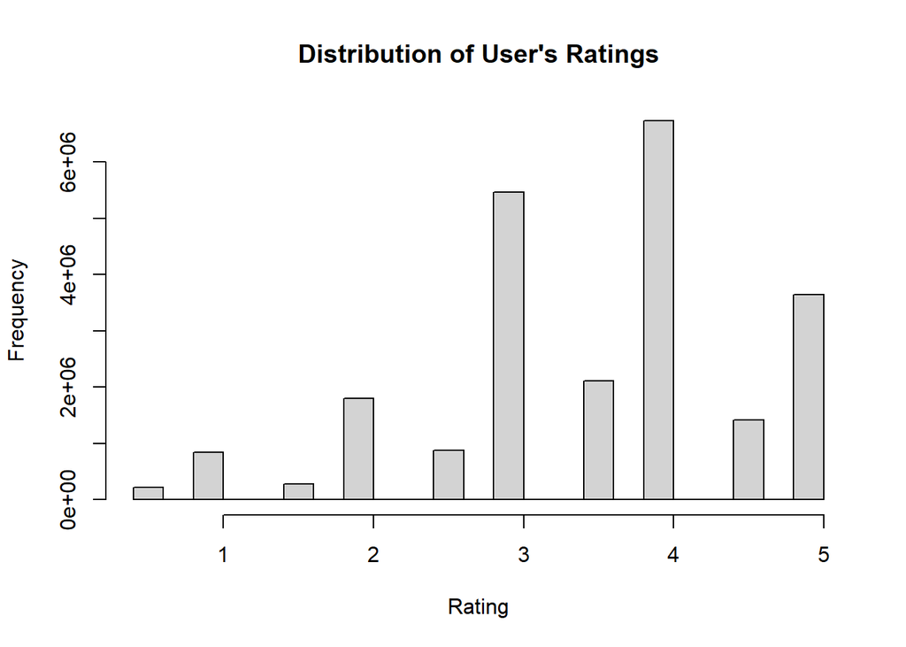

```r
hist(edx$rating, main="Distribution of User's Ratings", xlab="Rating")
```

**Overview of Rating Frequency through Months and Years**

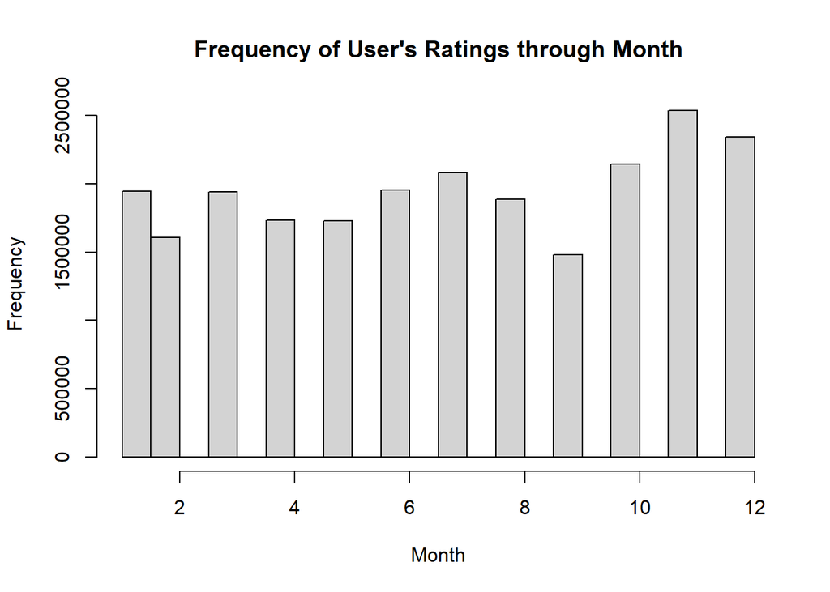

```r
hist(edx$monthOfRate, main="Frequency of User's Ratings through Month", xlab="Month")
```

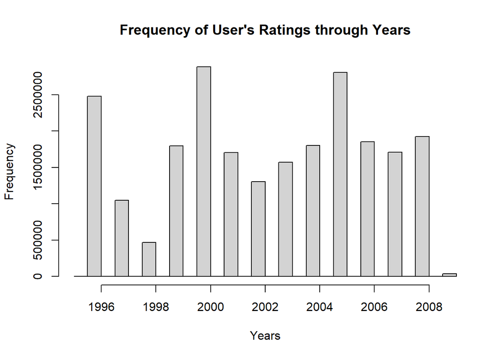

```r
hist(edx$yearOfRate, main="Frequency of User's Ratings through Years", xlab="Years")
```

### Numbers of Ratings per Movie

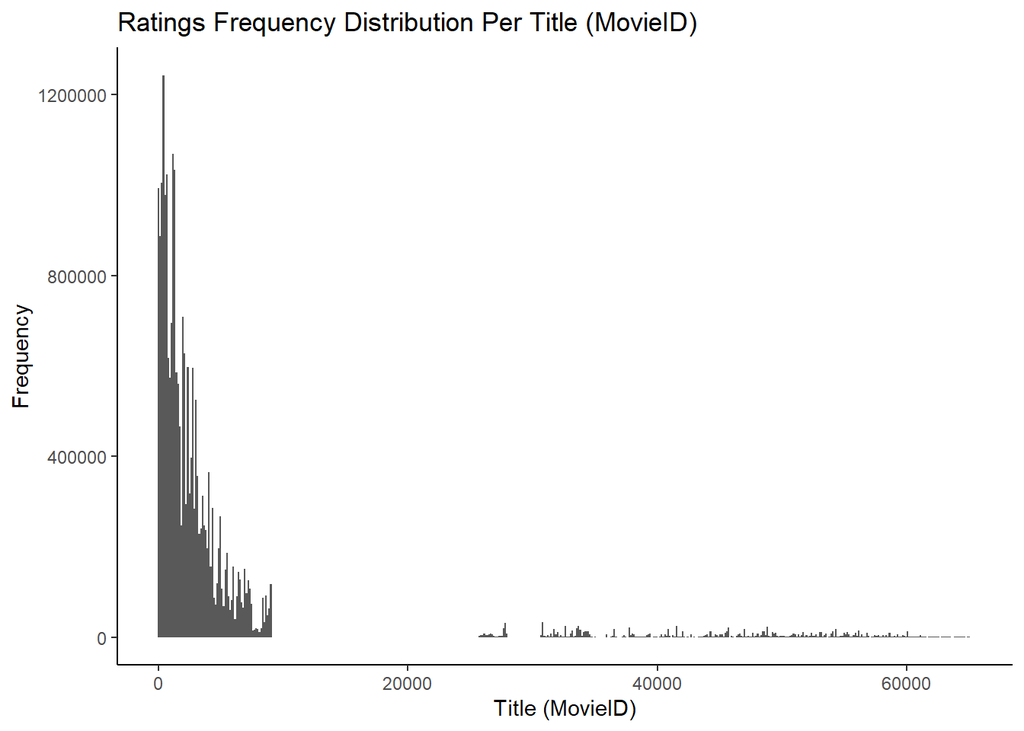

```r
   ggplot(edx, aes(movieId)) +
   theme_classic()  +
   geom_histogram(bins=500) +
   labs(title = "Ratings Frequency Distribution Per Title (MovieID)",
        x = "Title (MovieID)",
        y = "Frequency")
```

### Top Rated Movies

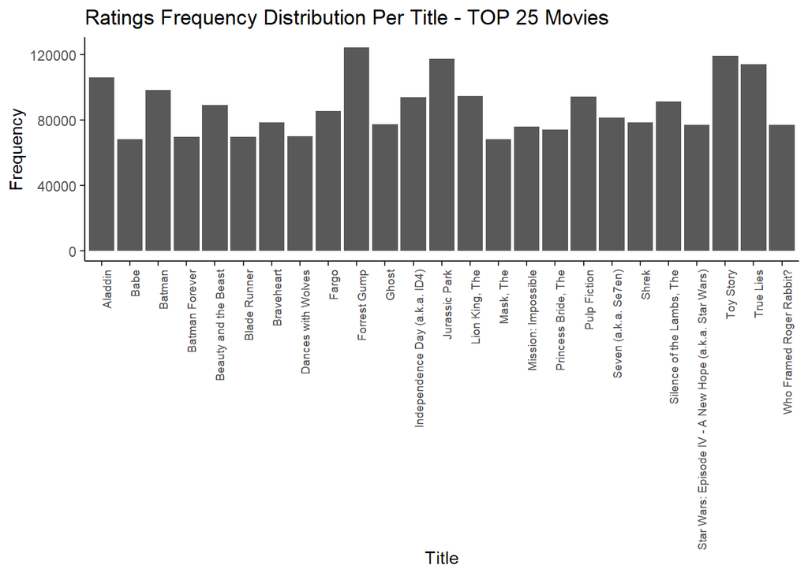

```r
edx %>%
   group_by(title) %>%
   summarise(count = n()) %>%
   arrange(desc(count)) %>%
   head(n=25) %>%
   ggplot(aes(title, count)) +
   theme_classic()  +
   geom_col() +
   theme(axis.text.x = element_text(angle = 90, hjust = 1, size = 7)) +
   labs(title = "Ratings Frequency Distribution Per Title - TOP 25 Movies",
        x = "Title",
        y = "Frequency")
```

```r
edx %>%
   group_by(title) %>%
   summarise(count = n()) %>%
   arrange(desc(count)) %>%
   head(n=25) %>%
   kable() %>%
   kable_styling(bootstrap_options = c("striped", "hover", "condensed", "responsive"),
                 position = "center",
                 font_size = 10,
                 full_width = FALSE)
```

| title | count |
| --- | --- |
| Forrest Gump | 124316 |
| Toy Story | 118950 |
| Jurassic Park | 117440 |
| True Lies | 114115 |
| Aladdin | 105865 |
| Batman | 98340 |
| Lion King, The | 94605 |
| Pulp Fiction | 94086 |
| Independence Day (a.k.a. ID4) | 93796 |
| Silence of the Lambs, The | 91146 |
| Beauty and the Beast | 89145 |
| Fargo | 85580 |
| Seven (a.k.a. Se7en) | 81244 |
| Braveheart | 78636 |
| Shrek | 78378 |
| Ghost | 77440 |
| Star Wars: Episode IV - A New Hope (a.k.a. Star Wars) | 77016 |
| Who Framed Roger Rabbit? | 76825 |
| Mission: Impossible | 75968 |
| Princess Bride, The | 74045 |
| Dances with Wolves | 70101 |
| Blade Runner | 69785 |
| Batman Forever | 69656 |
| Mask, The | 68172 |
| Babe | 68124 |

### Mean Distribution per Title (Movie ID)

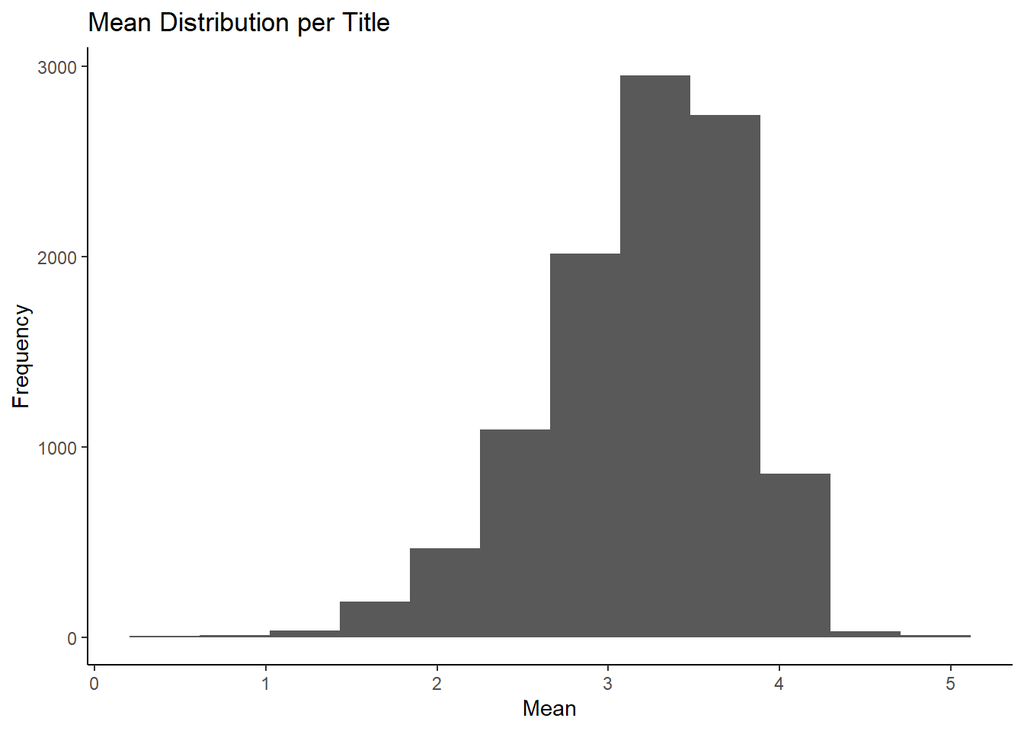

```r
edx %>%
   group_by(title) %>%
   summarise(mean = mean(rating)) %>%
   ggplot(aes(mean)) +
   theme_classic()  +
   geom_histogram(bins=12) +
   labs(title = "Mean Distribution per Title",
        x = "Mean",
        y = "Frequency")
```

```r
edx %>%
   group_by(title) %>%
   summarise(mean = mean(rating)) %>%
   arrange(desc(mean)) %>%
   head(n=25) %>%
   kable() %>%
   kable_styling(bootstrap_options = c("striped", "hover", "condensed", "responsive"),
                 position = "center",
                 font_size = 10,
                 full_width = FALSE)
```

| title | mean |
| --- | --- |
| Blue Light, The (Das Blaue Licht) | 5.000000 |
| Fighting Elegy (Kenka erejii) | 5.000000 |
| Hellhounds on My Trail | 5.000000 |
| Satan’s Tango (Sátántangó) | 5.000000 |
| Shadows of Forgotten Ancestors | 5.000000 |
| Sun Alley (Sonnenallee) | 5.000000 |
| Constantine’s Sword | 4.750000 |
| Human Condition II, The (Ningen no joken II) | 4.750000 |
| Human Condition III, The (Ningen no joken III) | 4.750000 |
| Who’s Singin’ Over There? (a.k.a. Who Sings Over There) (Ko to tamo peva) | 4.750000 |
| Class, The (Entre les Murs) | 4.666667 |
| I’m Starting From Three (Ricomincio da Tre) | 4.666667 |
| Bad Blood (Mauvais sang) | 4.500000 |
| Demon Lover Diary | 4.500000 |
| End of Summer, The (Kohayagawa-ke no aki) | 4.500000 |
| Kansas City Confidential | 4.500000 |
| Ladrones | 4.500000 |
| Life of Oharu, The (Saikaku ichidai onna) | 4.500000 |
| Man Named Pearl, A | 4.500000 |
| Mickey | 4.500000 |
| Please Vote for Me | 4.500000 |
| Power of Nightmares: The Rise of the Politics of Fear, The | 4.500000 |
| Testament of Orpheus, The (Testament d’Orphée) | 4.500000 |
| Tokyo! | 4.500000 |
| Valerie and Her Week of Wonders (Valerie a týden divu) | 4.500000 |

### Median Distribution per Title (Movie ID)

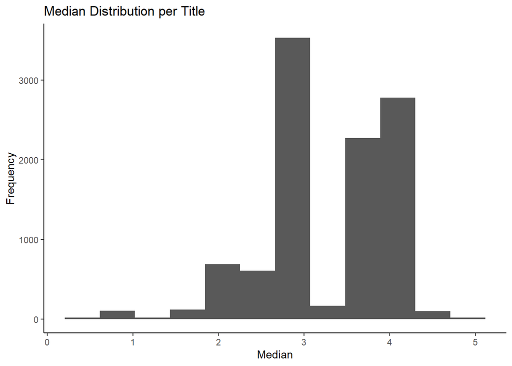

```r
edx %>%
   group_by(title) %>%
   summarise(median = median(rating)) %>%
   ggplot(aes(median)) +
   theme_classic()  +
   geom_histogram(bins=12) +
   labs(title = "Median Distribution per Title",
        x = "Median",
        y = "Frequency")
```

```r
edx %>%
   group_by(title) %>%
   summarise(median = median(rating)) %>%
   arrange(desc(median)) %>%
   head(n=25) %>%
   kable() %>%
   kable_styling(bootstrap_options = c("striped", "hover", "condensed", "responsive"),
                 position = "center",
                 font_size = 10,
                 full_width = FALSE)
```

| title | median |
| --- | --- |
| Blue Light, The (Das Blaue Licht) | 5.00 |
| Class, The (Entre les Murs) | 5.00 |
| Fighting Elegy (Kenka erejii) | 5.00 |
| Godfather, The | 5.00 |
| Hellhounds on My Trail | 5.00 |
| Kids of Survival | 5.00 |
| Satan’s Tango (Sátántangó) | 5.00 |
| Shadows of Forgotten Ancestors | 5.00 |
| Shawshank Redemption, The | 5.00 |
| Sun Alley (Sonnenallee) | 5.00 |
| Who’s Singin’ Over There? (a.k.a. Who Sings Over There) (Ko to tamo peva) | 5.00 |
| World of Apu, The (Apur Sansar) | 5.00 |
| Constantine’s Sword | 4.75 |
| Human Condition II, The (Ningen no joken II) | 4.75 |
| Human Condition III, The (Ningen no joken III) | 4.75 |
| 400 Blows, The (Les Quatre cents coups) | 4.50 |
| 49 Up | 4.50 |
| Amelie (Fabuleux destin d’Amélie Poulain, Le) | 4.50 |
| American Beauty | 4.50 |
| Andrei Rublev (Andrey Rublyov) | 4.50 |
| Bad Blood (Mauvais sang) | 4.50 |
| Best of Youth, The (La Meglio gioventù) | 4.50 |
| Cabeza de Vaca | 4.50 |
| Casablanca | 4.50 |
| Celebration, The (Festen) | 4.50 |

## Genre Analysis

### Rating Distribution per Genre

**Overview of Rating distribution over Genre**

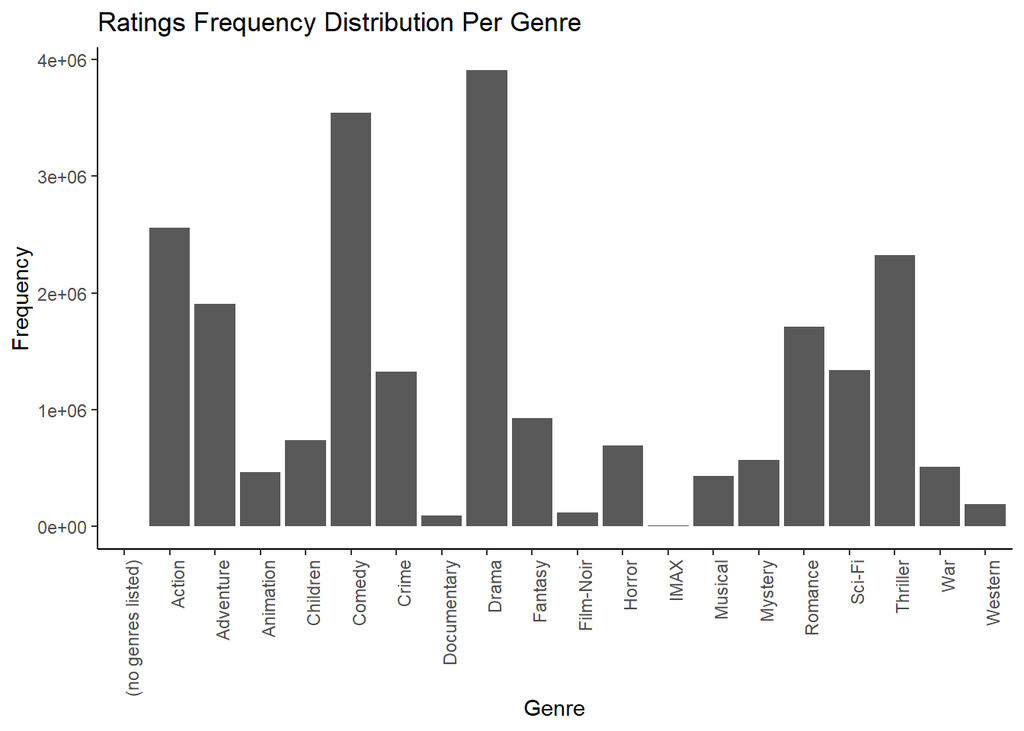

```r
edx %>%
   group_by(genre) %>%
   summarise(count = n()) %>%
   ggplot(aes(genre, count)) +
   theme_classic()  +
   geom_col() +
   theme(axis.text.x = element_text(angle = 90, hjust = 1)) +
   labs(title = "Ratings Frequency Distribution Per Genre",
        x = "Genre",
        y = "Frequency")
```

```r
edx %>%
   group_by(genre) %>%
   summarise(count = n()) %>%
   arrange(desc(count)) %>%
   kable() %>%
   kable_styling(bootstrap_options = c("striped", "hover", "condensed", "responsive"),
                 position = "center",
                 font_size = 10,
                 full_width = FALSE)
```

| genre | count |
| --- | --- |
| Drama | 3910127 |
| Comedy | 3540930 |
| Action | 2560545 |
| Thriller | 2325899 |
| Adventure | 1908892 |
| Romance | 1712100 |
| Sci-Fi | 1341183 |
| Crime | 1327715 |
| Fantasy | 925637 |
| Children | 737994 |
| Horror | 691485 |
| Mystery | 568332 |
| War | 511147 |
| Animation | 467168 |
| Musical | 433080 |
| Western | 189394 |
| Film-Noir | 118541 |
| Documentary | 93066 |
| IMAX | 8181 |
| (no genres listed) | 7 |

### Mean Distribution per Genre

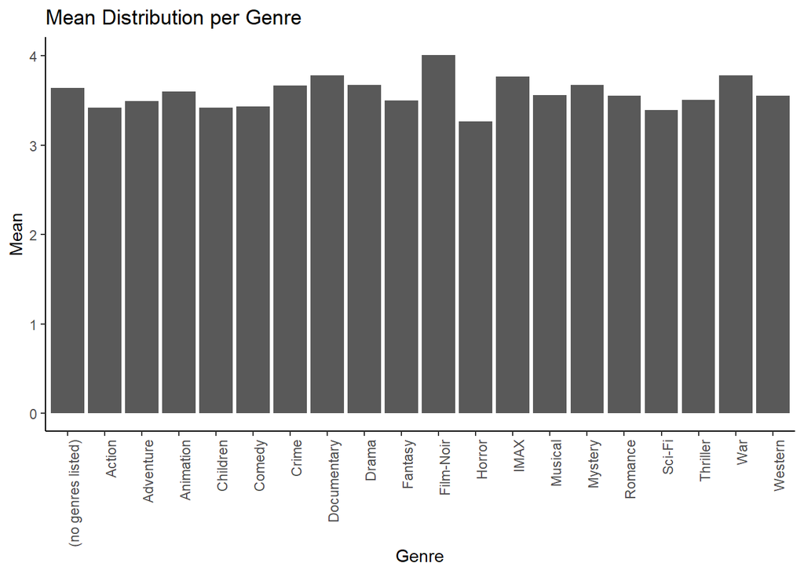

```r
edx %>%
   group_by(genre) %>%
   summarise(mean = mean(rating)) %>%
   ggplot(aes(genre, mean)) +
   theme_classic()  +
   geom_col() +
   theme(axis.text.x = element_text(angle = 90, hjust = 1)) +
   labs(title = "Mean Distribution per Genre",
        x = "Genre",
        y = "Mean")
```

```r
edx %>%
   group_by(genre) %>%
   summarise(mean = mean(rating)) %>%
   arrange(desc(mean)) %>%
   head(n=35) %>%
   kable() %>%
   kable_styling(bootstrap_options = c("striped", "hover", "condensed", "responsive"),
                 position = "center",
                 font_size = 10,
                 full_width = FALSE)
```

| genre | mean |
| --- | --- |
| Film-Noir | 4.011625 |
| Documentary | 3.783487 |
| War | 3.780813 |
| IMAX | 3.767693 |
| Mystery | 3.677001 |
| Drama | 3.673131 |
| Crime | 3.665925 |
| (no genres listed) | 3.642857 |
| Animation | 3.600644 |
| Musical | 3.563305 |
| Western | 3.555918 |
| Romance | 3.553813 |
| Thriller | 3.507676 |
| Fantasy | 3.501946 |
| Adventure | 3.493544 |
| Comedy | 3.436908 |
| Action | 3.421405 |
| Children | 3.418715 |
| Sci-Fi | 3.395743 |
| Horror | 3.269815 |

### Median Distribution per Genre

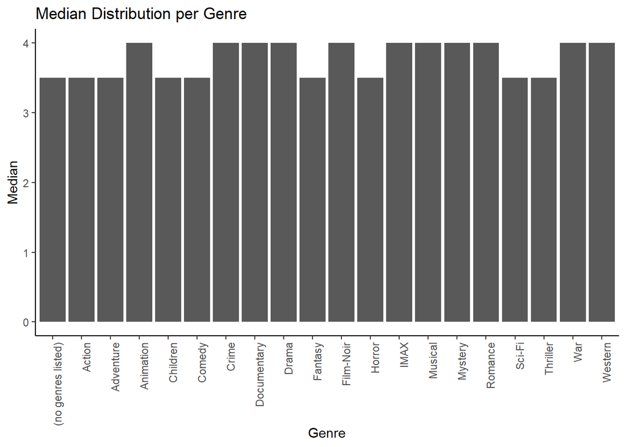

```r
edx %>%
   group_by(genre) %>%
   summarise(median = median(rating)) %>%
   ggplot(aes(genre, median)) +
   theme_classic()  +
   geom_col() +
   theme(axis.text.x = element_text(angle = 90, hjust = 1)) +
   labs(title = "Median Distribution per Genre",
        x = "Genre",
        y = "Median")
```

```r
edx %>%
   group_by(genre) %>%
   summarise(median = median(rating)) %>%
   arrange(desc(median)) %>%
   head(n=35) %>%
   kable() %>%
   kable_styling(bootstrap_options = c("striped", "hover", "condensed", "responsive"),
                 position = "center",
                 font_size = 10,
                 full_width = FALSE)
```

| genre | median |
| --- | --- |
| Animation | 4.0 |
| Crime | 4.0 |
| Documentary | 4.0 |
| Drama | 4.0 |
| Film-Noir | 4.0 |
| IMAX | 4.0 |
| Musical | 4.0 |
| Mystery | 4.0 |
| Romance | 4.0 |
| War | 4.0 |
| Western | 4.0 |
| (no genres listed) | 3.5 |
| Action | 3.5 |
| Adventure | 3.5 |
| Children | 3.5 |
| Comedy | 3.5 |
| Fantasy | 3.5 |
| Horror | 3.5 |
| Sci-Fi | 3.5 |
| Thriller | 3.5 |

# Analysis - Model Building and Evaluation

## Naive Baseline Model

The simplest model that someone can build, is a Naive Model that predict ALWAYS the mean. In this case, the mean is approximately 3.5.

```r
paste("The mean is:", as.character(mean(edx$rating)))
```

```
## [1] "The mean is: 3.52701897954609"
```

### Naive Mean-Baseline Model

The formula used is:

$$Y_{u,i} = \hat{\mu} + \varepsilon_{u,i}$$

With $\hat{\mu}$ is the mean and $\varepsilon_{i,u}$ is the independent errors sampled from the same distribution centered at 0.

```r
# Calculate the average of all movies

mu_hat <- mean(edx$rating)

# Predict the RMSE on the validation set

rmse_mean_model_result <- RMSE(validation$rating, mu_hat)

# Creating a results dataframe that contains all RMSE results

results <- data.frame(model="Naive Mean-Baseline Model", RMSE=rmse_mean_model_result)
```

The RMSE on the `validation` dataset is **1.05**. It is very far for the target RMSE (below 0.87) and that indicates poor performance for the model.

## Movie-Based Model, a Content-based Approach

The first Non-Naive Model takes into account the content. In this case the movies that are rated higher or lower resperct to each other.

The formula used is:

$$Y_{u,i} = \hat{\mu} + b_i + \epsilon_{u,i}$$

With $\hat{\mu}$ is the mean and $\varepsilon_{i,u}$ is the independent errors sampled from the same distribution centered at 0. The $b_i$ is a measure for the popularity of movie $i$, i.e. the bias of movie $i$.

```r
# Calculate the average of all movies

mu_hat <- mean(edx$rating)

# Calculate the average by movie

movie_avgs <- edx %>%
   group_by(movieId) %>%
   summarize(b_i = mean(rating - mu_hat))

# Compute the predicted ratings on validation dataset

rmse_movie_model <- validation %>%
   left_join(movie_avgs, by='movieId') %>%
   mutate(pred = mu_hat + b_i) %>%
   pull(pred)

rmse_movie_model_result <- RMSE(validation$rating, rmse_movie_model)

# Adding the results to the results dataset

results <- results %>% add_row(model="Movie-Based Model", RMSE=rmse_movie_model_result)
```

The RMSE on the `validation` dataset is **0.94**. It better than the Naive Mean-Baseline Model, but it is also very far from the target RMSE (below 0.87) and that indicates poor performance for the model.

## Movie + User Model, a User-based approach

The second Non-Naive Model consider that the users have different tastes and rate differently.

The formula used is:

$$Y_{u,i} = \hat{\mu} + b_i + b_u + \epsilon_{u,i}$$

With $\hat{\mu}$ is the mean and $\varepsilon_{i,u}$ is the independent errors sampled from the same distribution centered at 0. The $b_i$ is a measure for the popularity of movie $i$, i.e. the bias of movie $i$. The $b_u$ is a measure for the mildness of user $u$, i.e. the bias of user $u$.

```r
# Calculate the average of all movies

mu_hat <- mean(edx$rating)

# Calculate the average by movie

movie_avgs <- edx %>%
   group_by(movieId) %>%
   summarize(b_i = mean(rating - mu_hat))

# Calculate the average by user

user_avgs <- edx %>%
   left_join(movie_avgs, by='movieId') %>%
   group_by(userId) %>%
   summarize(b_u = mean(rating - mu_hat - b_i))

# Compute the predicted ratings on validation dataset

rmse_movie_user_model <- validation %>%
   left_join(movie_avgs, by='movieId') %>%
   left_join(user_avgs, by='userId') %>%
   mutate(pred = mu_hat + b_i + b_u) %>%
   pull(pred)

rmse_movie_user_model_result <- RMSE(validation$rating, rmse_movie_user_model)

# Adding the results to the results dataset

results <- results %>% add_row(model="Movie+User Based Model", RMSE=rmse_movie_user_model_result)
```

## Movie + User + Genre Model, the Genre Popularity

The formula used is:

$$Y_{u,i} = \hat{\mu} + b_i + b_u + b_{u,g} + \epsilon_{u,i}$$

```r
# Calculate the average of all movies

mu_hat <- mean(edx$rating)

# Calculate the average by movie

movie_avgs <- edx %>%
   group_by(movieId) %>%
   summarize(b_i = mean(rating - mu_hat))

# Calculate the average by user

user_avgs <- edx %>%
   left_join(movie_avgs, by='movieId') %>%
   group_by(userId) %>%
   summarize(b_u = mean(rating - mu_hat - b_i))

genre_pop <- edx %>%
   left_join(movie_avgs, by='movieId') %>%
   left_join(user_avgs, by='userId') %>%
   group_by(genre) %>%
   summarize(b_u_g = mean(rating - mu_hat - b_i - b_u))

# Compute the predicted ratings on validation dataset

rmse_movie_user_genre_model <- validation %>%
   left_join(movie_avgs, by='movieId') %>%
   left_join(user_avgs, by='userId') %>%
   left_join(genre_pop, by='genre') %>%
   mutate(pred = mu_hat + b_i + b_u + b_u_g) %>%
   pull(pred)

rmse_movie_user_genre_model_result <- RMSE(validation$rating, rmse_movie_user_genre_model)

# Adding the results to the results dataset

results <- results %>% add_row(model="Movie+User+Genre Based Model", RMSE=rmse_movie_user_genre_model_result)
```

## Regularization

The regularization method allows us to add a penalty $\lambda$ (lambda) to penalizes movies with large estimates from a small sample size. In order to optimize $b_i$, it necessary to use this equation:

$$\frac{1}{N} \sum_{u,i} (y_{u,i} - \mu - b_{i})^{2} + \lambda \sum_{i} b_{i}^2$$

reduced to this equation:

$$\hat{b_{i}} (\lambda) = \frac{1}{\lambda + n_{i}} \sum_{u=1}^{n_{i}} (Y_{u,i} - \hat{\mu})$$

### Regularized Movie-Based Model

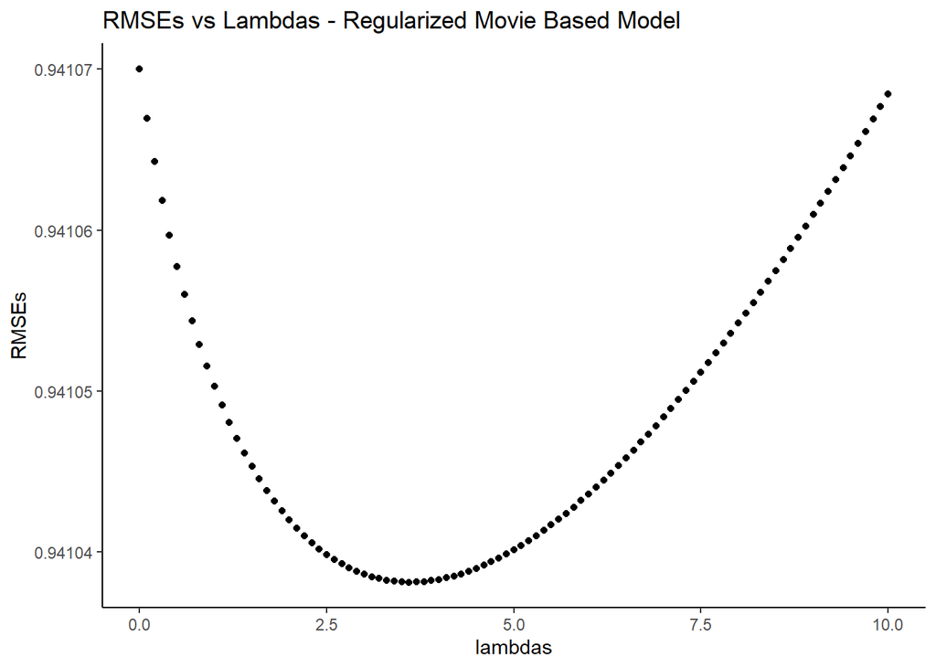

```r
# Calculate the average of all movies

mu_hat <- mean(edx$rating)

# Define a table of lambdas

lambdas <- seq(0, 10, 0.1)

# Compute the predicted ratings on validation dataset using different values of lambda

rmses <- sapply(lambdas, function(lambda) {

  # Calculate the average by user

   b_i <- edx %>%
      group_by(movieId) %>%
      summarize(b_i = sum(rating - mu_hat) / (n() + lambda))

   # Compute the predicted ratings on validation dataset

   predicted_ratings <- validation %>%
      left_join(b_i, by='movieId') %>%
      mutate(pred = mu_hat + b_i) %>%
      pull(pred)

   # Predict the RMSE on the validation set

   return(RMSE(validation$rating, predicted_ratings))
})

# plot the result of lambdas

df <- data.frame(RMSE = rmses, lambdas = lambdas)

ggplot(df, aes(lambdas, rmses)) +
   theme_classic()  +
   geom_point() +
   labs(title = "RMSEs vs Lambdas - Regularized Movie Based Model",
        y = "RMSEs",
        x = "lambdas")
```

```r
# Get the lambda value that minimize the RMSE
min_lambda <- lambdas[which.min(rmses)]

# Predict the RMSE on the validation set

rmse_regularized_movie_model <- min(rmses)

# Adding the results to the results dataset

results <- results %>% add_row(model="Regularized Movie-Based Model", RMSE=rmse_regularized_movie_model)
```

### Regularized Movie+User Model

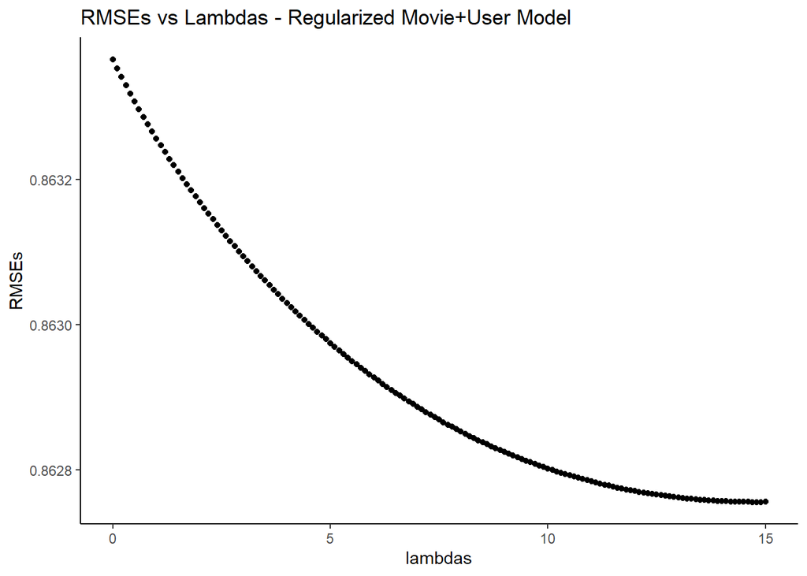

```r
# Calculate the average of all movies

mu_hat <- mean(edx$rating)

# Define a table of lambdas

lambdas <- seq(0, 15, 0.1)

# Compute the predicted ratings on validation dataset using different values of lambda

rmses <- sapply(lambdas, function(lambda) {

   # Calculate the average by user

   b_i <- edx %>%
      group_by(movieId) %>%
      summarize(b_i = sum(rating - mu_hat) / (n() + lambda))

   # Calculate the average by user

   b_u <- edx %>%
      left_join(b_i, by='movieId') %>%
      group_by(userId) %>%
      summarize(b_u = sum(rating - b_i - mu_hat) / (n() + lambda))

   # Compute the predicted ratings on validation dataset

   predicted_ratings <- validation %>%
      left_join(b_i, by='movieId') %>%
      left_join(b_u, by='userId') %>%
      mutate(pred = mu_hat + b_i + b_u) %>%
      pull(pred)

   # Predict the RMSE on the validation set

   return(RMSE(validation$rating, predicted_ratings))
})

# plot the result of lambdas

df <- data.frame(RMSE = rmses, lambdas = lambdas)

ggplot(df, aes(lambdas, rmses)) +
   theme_classic()  +
   geom_point() +
   labs(title = "RMSEs vs Lambdas - Regularized Movie+User Model",
        y = "RMSEs",
        x = "lambdas")
```

```r
# Get the lambda value that minimize the RMSE

min_lambda <- lambdas[which.min(rmses)]

# Predict the RMSE on the validation set

rmse_regularized_movie_user_model <- min(rmses)

# Adding the results to the results dataset

results <- results %>% add_row(model="Regularized Movie+User Based Model", RMSE=rmse_regularized_movie_user_model)
```

### Regularized Movie+User+Genre Model

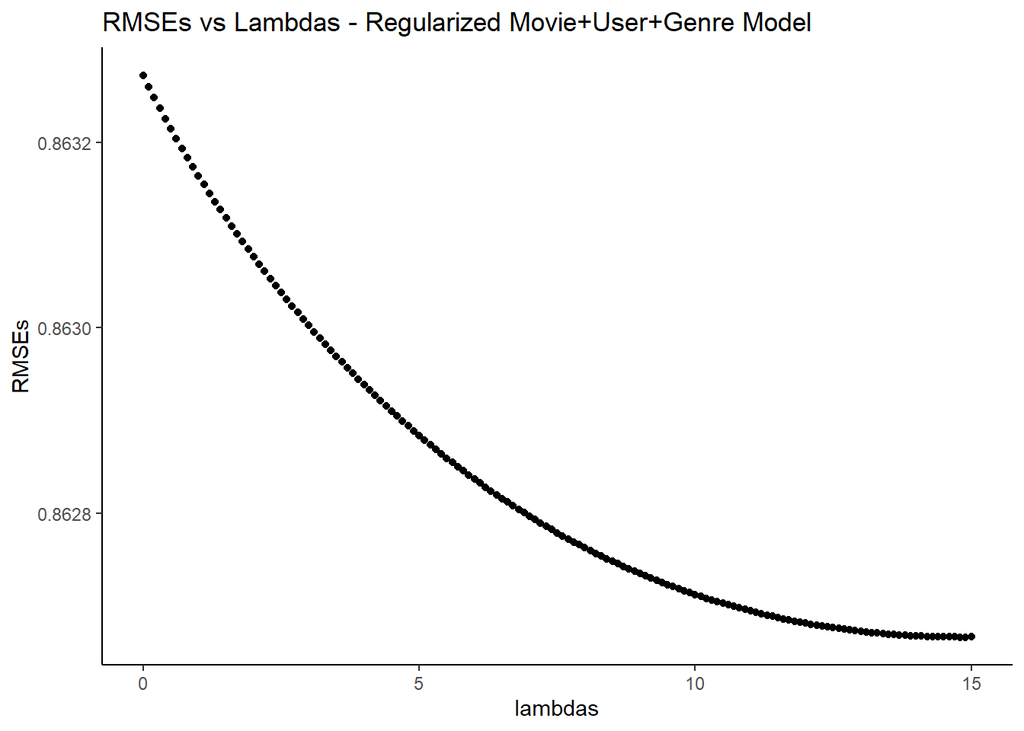

```r
# Calculate the average of all movies

mu_hat <- mean(edx$rating)

# Define a table of lambdas

lambdas <- seq(0, 15, 0.1)

# Compute the predicted ratings on validation dataset using different values of lambda

rmses <- sapply(lambdas, function(lambda) {

   # Calculate the average by user

   b_i <- edx %>%
      group_by(movieId) %>%
      summarize(b_i = sum(rating - mu_hat) / (n() + lambda))

   # Calculate the average by user

   b_u <- edx %>%
      left_join(b_i, by='movieId') %>%
      group_by(userId) %>%
      summarize(b_u = sum(rating - b_i - mu_hat) / (n() + lambda))

    b_u_g <- edx %>%
      left_join(b_i, by='movieId') %>%
      left_join(b_u, by='userId') %>%
      group_by(genre) %>%
      summarize(b_u_g = sum(rating - b_i - mu_hat - b_u) / (n() + lambda))

   # Compute the predicted ratings on validation dataset

   predicted_ratings <- validation %>%
      left_join(b_i, by='movieId') %>%
      left_join(b_u, by='userId') %>%
      left_join(b_u_g, by='genre') %>%
      mutate(pred = mu_hat + b_i + b_u + b_u_g) %>%
      pull(pred)

   # Predict the RMSE on the validation set

   return(RMSE(validation$rating, predicted_ratings))
})

# plot the result of lambdas

df <- data.frame(RMSE = rmses, lambdas = lambdas)

ggplot(df, aes(lambdas, rmses)) +
   theme_classic()  +
   geom_point() +
   labs(title = "RMSEs vs Lambdas - Regularized Movie+User+Genre Model",
        y = "RMSEs",
        x = "lambdas")
```

```r
# Get the lambda value that minimize the RMSE

min_lambda <- lambdas[which.min(rmses)]

# Predict the RMSE on the validation set

rmse_regularized_movie_user_genre_model <- min(rmses)

# Adding the results to the results dataset

results <- results %>% add_row(model="Regularized Movie+User+Genre Based Model", RMSE=rmse_regularized_movie_user_genre_model)
```

# Results

This is the summary results for all the model builted, trained on `edx` dataset and validated on the `validation` dataset.

```r
# Shows the results

results %>%
   kable() %>%
   kable_styling(bootstrap_options = c("striped", "hover", "condensed", "responsive"),
             position = "center",
             font_size = 10,
             full_width = FALSE)
```

| model | RMSE |
| --- | --- |
| Naive Mean-Baseline Model | 1.0525579 |
| Movie-Based Model | 0.9410700 |
| Movie+User Based Model | 0.8633660 |
| Movie+User+Genre Based Model | 0.8632723 |
| Regularized Movie-Based Model | 0.9410381 |
| Regularized Movie+User Based Model | 0.8627554 |
| Regularized Movie+User+Genre Based Model | 0.8626664 |

# Conclusion